# Attitudes and Awareness Surrounding Female Circumcision in Egypt

An Analysis of the 2014 Egypt Demographic and Health Survey

Tshering Samdrup

`05.08.2026`

# Introduction

## What is Female circumcision?

Female circumcision is a term that has been used to describe a range of procedures involving the female external genitalia. Today, the term female genital mutilation (FGM) is commonly used by the World Health Organization because these procedures have no medical benefit and can cause significant harm.

FGM includes procedures such as:

1. Partial or total removal of the clitoris (clitoridectomy).
2. Partial or total removal of the clitoris and the labia minora, sometimes also the labia majora (excision).
3. Narrowing of the vaginal opening by cutting and repositioning the labia (infibulation), the most extensive form.
4. Other harmful procedures to the female genitalia for non-medical reasons, such as pricking, piercing, scraping, or cauterizing.

FGM is usually carried out during infancy, childhood, or adolescence in some communities for cultural, social, or religious reasons. However, it is not required by any major religion, and many religious leaders oppose the practice.

Possible health effects include:

- Severe pain and bleeding.
- Infection.
- Difficulty urinating.
- Problems with menstruation.
- Pain during sexual intercourse.
- Complications during childbirth.
- Psychological trauma.

Many countries have laws banning FGM, and international health and human rights organizations work to eliminate the practice while supporting affected women and girls. It’s important to distinguish FGM from female genital cosmetic surgery performed on consenting adults for medical or cosmetic reasons, as these are different in terms of consent, purpose, and legal and ethical considerations.

## Female circumcision in Egypt

Female genital cutting (FGC/FGM) is a major public health and human rights issue in Egypt because it remains widely practiced and affects a very large share of women and girls. Available sources indicate a prevalence of about 87.2% among women aged 15–49, and Egypt has the largest absolute number of women and girls affected globally

## Public health relevance

It matters for public health because it can cause immediate harm such as pain, bleeding, infection, and sometimes death, and longer-term harms including urinary and menstrual problems, sexual health problems, and childbirth complications.

The practice also creates a burden on health services because many procedures are performed on girls before age 12, and a large share are now done by health professionals, which can normalize the practice rather than prevent it.

It is a human rights issue because it involves non-consensual injury to children and women, violating bodily integrity, dignity, and the right to be free from violence and harmful traditional practices.

The fact that it is often performed on minors makes the consent issue especially serious, since girls cannot meaningfully choose whether to undergo it.

## Objective

This report aims to:

- Assess women’s awareness of and recent exposure to information about female circumcision in Egypt
- Identify the most common sources through which women receive this information (e.g., television, radio, community health workers, family members)
- Examine attitudes toward female circumcision — including beliefs about its health risks, social justifications, and whether the practice should continue
- Explore how awareness, information sources, and attitudes vary across key socio-demographic groups, including education level, place of residence (urban/rural), household wealth, and age
- Highlight patterns that could help inform more targeted public health messaging and community outreach efforts aimed at reducing the practice

## Data Source

This report uses data from the **2014 Egypt Demographic and Health Survey (DHS)**, specifically the **Women’s Individual Recode** dataset obtained from [here](https://dhsprogram.com/data/dataset/Egypt_Standard-DHS_2014.cfm?flag=0). . This survey was conducted by the Ministry of Health and Population and El-Zanaty & Associates, and covers ever-married women aged 15-49 across Egypt (excluding North and South Sinai governorates). The full sample includes 21,762 women.

The variables used in this analysis fall into two broad categories:

- **Socio-demographic variables**: age, highest level of education, place of residence (urban/rural), household wealth index, and region
- **Female circumcision variables**: whether daughters remain uncircumcised, recent exposure to information on the topic, sources of that information, and attitudes toward the practice (e.g., whether it can cause death, whether it should continue)

All analyses in this report are based on **unweighted** counts and percentages. Because DHS uses a complex, stratified sampling design, official DHS publications apply sampling weights to produce nationally representative estimates; as a result, the figures presented here may differ slightly from those in official DHS reports.

```
## [1] "agree"    "disagree" "dk"
```

# Results

## Where Women Heard About Female Circumcision

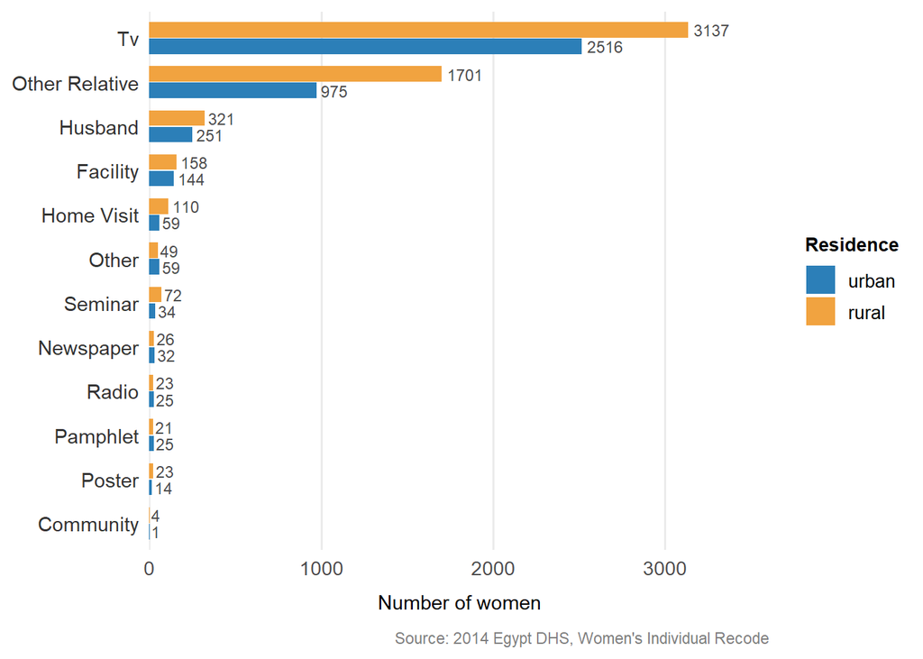

Television emerges as by far the most common channel through which women learned about female circumcision, reaching over 3,100 rural women and 2,500 urban women — several times more than any other source. Learning from a relative is the second most common pathway, again more prevalent among rural women (1,701) than urban women (975). All other channels — husbands, health facilities, home visits, and print media — play a comparatively minor role, each reaching fewer than 350 women in either group. This pattern suggests that mass media campaigns, rather than clinic-based or print outreach, may offer the greatest reach for public health messaging on this topic, particularly in rural areas.

## Proportion of Women with at Least One Uncut Daughter by household wealth index

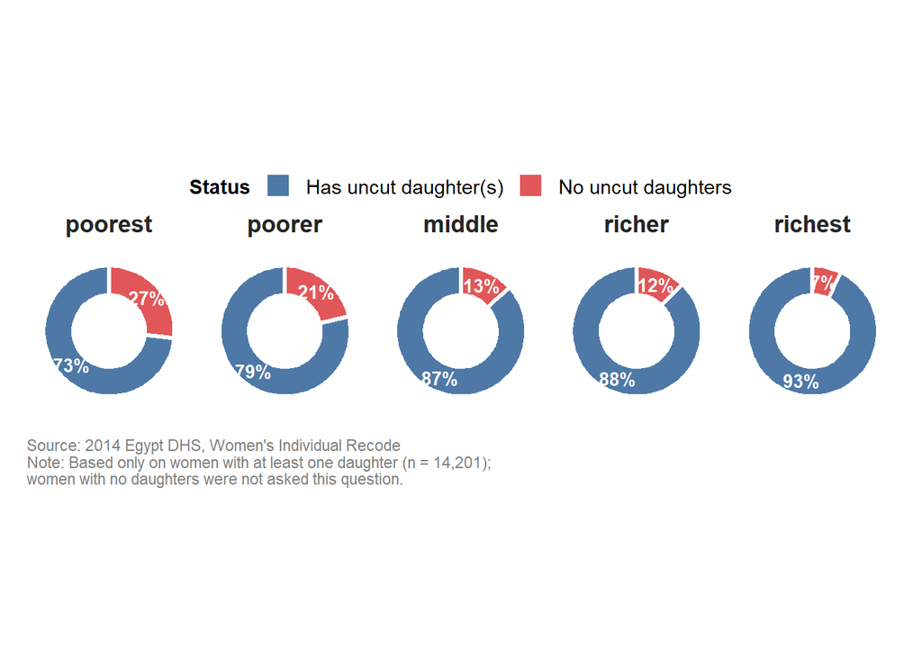

## Knowledge about Circumcision

### Agreement with Attitude Statements on Female Circumcision Percent agreeing, among women who gave a definite answer

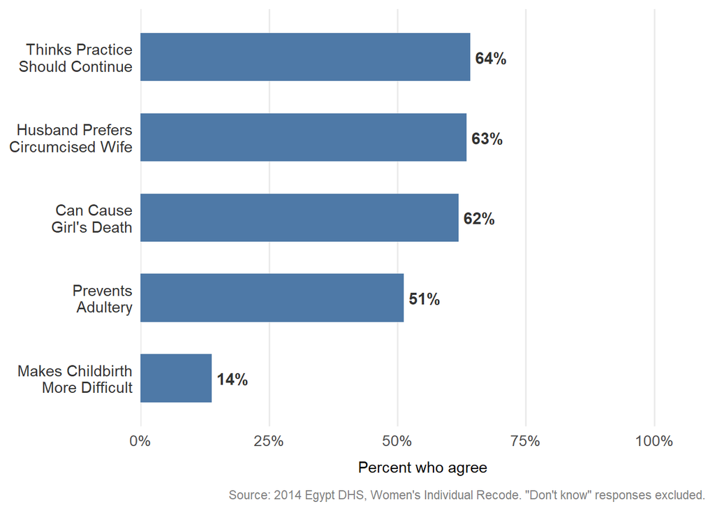

### Belief that Circumcision Can Cause a Girl’s Death by education level attained

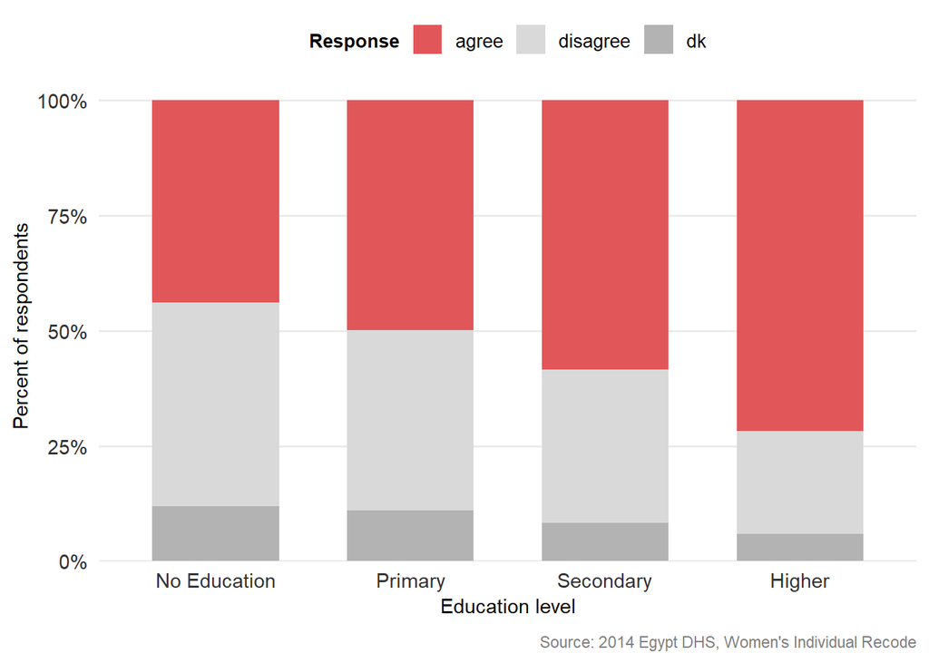

### Age Distribution by Belief on Whether Circumcision Should Continue

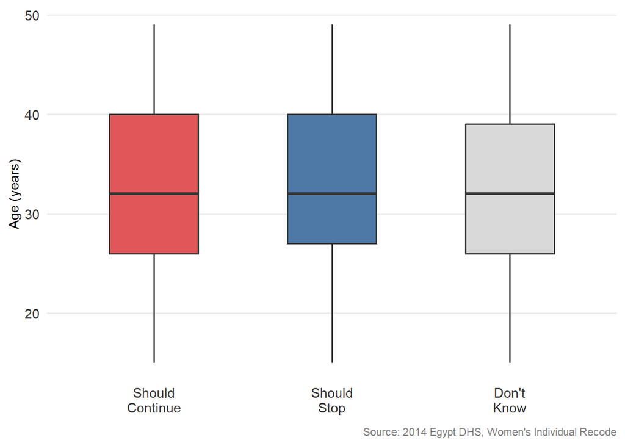

Age shows little meaningful variation across attitude groups. Women who believe circumcision should continue, those who believe it should stop, and those who are unsure all have a nearly identical median age of approximately 32 years, with broadly overlapping age ranges. This suggests that attitudes toward the practice are not strongly driven by generational differences — younger and older women hold similar views in roughly similar proportions. This is a notable finding on its own: rather than expecting attitude change to occur gradually as younger, differently educated cohorts age into the surveyed population, these results suggest that other factors — such as education level or household wealth, as seen in earlier charts — may be more powerful drivers of attitude than age alone.

Agreement with Attitude Statements on Female Circumcision

By education level, 2014 Egypt DHS

| Education Level | N | Percent Who Agree That... Should Continue | Percent Who Agree That... Husband Prefers | Percent Who Agree That... Prevents Adultery | Percent Who Agree That... Harder Childbirth | Percent Who Agree That... Can Cause Death |
| --- | --- | --- | --- | --- | --- | --- |
| No Education | 4859 | 60.9% | 62.6% | 55.5% | 11.3% | 43.9% |
| Primary | 2179 | 54.3% | 56.0% | 50.8% | 12.2% | 49.8% |
| Secondary | 11527 | 46.8% | 46.2% | 42.6% | 10.0% | 58.4% |
| Higher | 3189 | 29.6% | 28.4% | 26.7% | 7.2% | 71.8% |

Source: 2014 Egypt Demographic and Health Survey, Women's Individual Recode. "Don't know" responses are excluded from percentages.

# Conclusion

This analysis of the 2014 Egypt DHS reveals that attitudes toward female circumcision remain widespread, but far from uniform across the population. Television and family members — not health facilities or formal print media — are by far the most common channels through which women learn about the practice, suggesting that mass media and community-based approaches may offer the greatest reach for future public health messaging, particularly in rural areas where these channels dominate even further.

Taken together, these findings suggest that public health efforts aimed at reducing female circumcision in Egypt may benefit most from continued investment in girls’ education and mass-media health messaging, rather than relying on the assumption that increased risk awareness or generational change will shift behavior on their own. Future research incorporating survey weights, and exploring the interaction between education and wealth more directly, would help clarify which of these factors plays the more decisive role.